# Least-Squares Batch Identification Algorithm - Example

Table of Contents

Identifying an ARX(2, 2) Stochastic Process ARX Process Simulation Generation of the Data The Dataset Plot the Process Data Persistency of Excitation and the Identifiability Condition The Identifiability Condition Identification - the LS Algorithm The Estimate Uncertainty The Witheness Test

## Identifying an ARX(2, 2) Stochastic Process

Consider the stationary stochastic process 𝒮

$\mathcal{S}: \qquad y(t) = \displaystyle+\frac{6}{5}\ y(t-1) - \frac{8}{25}\,y(t-2) + u(t-1) +\frac{1}{2}\,u(t-2) + \xi(t)$

$\xi(\cdot ) \sim \mathrm{WN}\left(0, 1\right)\;,\quad u(\cdot) \sim \mathrm{WN}\left(0,\,4\right) \qquad e(\cdot), u(\cdot) \, \, \textrm{uncorrelated}$

$Y = \big\{ y(1),\, y(2),\, \ldots y(N_1) \big\} \qquad U = \big\{ u(1),\, u(2),\, \ldots u(N_1) \big\}$

Consider the model ℳ

$\mathcal{M}\left(\vartheta\right) : y(t) = a_1 \,y(t-1) +a_2\,y(t-2) + b_1\,u(t-1) + b_2\, u(t-2) + \eta(t) \qquad \mathrm{var}\left[\eta\left(\cdot\right)\right]= \lambda^2$

and let us identify the model. Let us resort to the Least-Squares technique. Then

$\vartheta = \left [ \begin{array}{c} a_1 \\ a_2 \\ b_1 \\ b_2 \end{array} \right ] \quad \varphi (t)= \left [ \begin{array}{c} y(t-1) \\ y(t-2) \\ u(t-1) \\ u(t-2) \\ \end{array} \right ]$

and hence

$\begin{array}{l} \mathcal{M} (\vartheta) \, \colon \quad y(t)= \varphi(t)^{\top} \, \vartheta+ \eta(t) \\ \widehat {\mathcal{M}} (\vartheta) \, \colon \quad \hat{y} \left(t \vert t-1 \right)= \varphi(t)^{\top} \, \vartheta \end{array}$

The predictor has a linear structure with respect to the vector ϑ of unknown parameters.

The prediction error $\epsilon(t)$ is given by

$\varepsilon (t)= y(t)-\hat{y} \left(t \vert t-1 \right)= y(t)- \varphi(t)^{\top} \, \vartheta$

Consider the quadratic cost function

$J(\vartheta)= \frac{1}{N_1} \sum_{t=1}^{N_1} \, [\varepsilon(t)]^2 = \frac{1}{N_1} \sum_{t=1}^{N_1} \, \left [ y(t)-\varphi(t)^{\top} \vartheta \right ]^2$

and the minimizing vector

$\vartheta^{\circ} = {\rm arg} \, \min_{\vartheta} \, J(\vartheta)$

If $\, \sum_{t=1}^N \,\varphi(t)\, \varphi(t)^{\top} \,$ is non-singular, one gets:

$\hat \vartheta_{N_1} = \left [ \,\sum_{t=1}^{N_1} \,\varphi(t) \, \varphi(t)^{\top} \, \right ]^{-1} \, \sum_{t=1}^{N_1} \, \varphi(t) \, y(t)$

and the estimate uncertainty is

$\mathrm{var}\left[\hat{\vartheta}_{N_1}\right] = \hat{\lambda}^2_{N_1}\, \left [ \,\sum_{t=1}^{N_1} \,\varphi(t) \, \varphi(t)^{\top} \, \right ]^{-1}$

where $\hat{\lambda}^2_{N_1}$is an empirical estimate of $\lambda^2$

$\hat{\lambda}^2_{N_1} = \frac{1}{N_1} \sum_{t=1}^{N_1} \, \left [ y(t)-\varphi(t)^{\top} \hat{\vartheta}_{N_1} \right ]^2$

The condition

${\rm det} \,\left [ \,\sum_{t=1}^N \,\varphi(t) \, \varphi(t)^{\top} \, \right ] \not= 0$

is called Identifiability Condition.

### ARX Process Simulation

#### Generation of the Data

```matlab
clear
close all
clc

N1 = 500; % the number of sample data to simulate and collect

var_xi = 1;  % the white noise variance
mean_xi = 0; % the white noise mean value

var_u = 4;  % the input variable variance
mean_u = 0; % the input variable mean value

Az1 = [1,  -6/5,  +8/25];
% the coefficients of the polynomial A(z) <-> 1 - a_1 * z^(-1) - a_2 * z^(-2)
%                                           z^2 - a_1 * z^1    - a_2 * z^ 0

Bz1 = [0,  1,  1/2];
% the coefficients of the polynomial B(z) <-> b_1 * z^(-1) + b_2 * z^(-2)
%                                             b_1 * z^1    + b_2 * z^ 0
Ts = 1; % sampling time
Gz1 = tf(Bz1, Az1, Ts, 'Variable', 'z^-1')
```

Gz1 = z^-1 + 0.5 z^-2 ------------------------ 1 - 1.2 z^-1 + 0.32 z^-2 Sample time: 1 seconds Discrete-time transfer function.

```matlab
Gz = tf(Bz1, Az1, Ts, 'Variable', 'z')
```

Gz = z + 0.5 ------------------ z^2 - 1.2 z + 0.32 Sample time: 1 seconds Discrete-time transfer function.

Let's estimate how long is the initial transient output of the filter $Gz) = \frac{B(z)}{A(z)}$:

```matlab
p_vector = pole(Gz); % the poles of W(z)
z_vector = zero(Gz); % the zeros of W(z)

slowest_pole = max(abs(p_vector));

zero_threshold = 1e-8;
% let's assume that the value is practically zero if less than or equal to zero_threshold
Ntransient = 50*(ceil(log10(zero_threshold)/log10(slowest_pole))+10); % a very raw estimation

N_TOT_data = N1 + Ntransient
```

N_TOT_data = 5150

```matlab
rng('shuffle');
%     seeds the random number generator based on the current
%     time so that RAND, RANDI, and RANDN produce a different sequence of
%     numbers after each time you call rng.
WN_samples = mean_xi + sqrt(var_xi)*randn(1, N_TOT_data); % the white noise sequence

rng('shuffle');
U_samples = mean_u + sqrt(var_u)*randn(1, N_TOT_data);    % the input u sequence
```

Remember: the stochastic process 𝒮 is an $ARX$ process

$\mathcal{S}: \qquad y(t) = \displaystyle+\frac{6}{5}\ y(t-1) - \frac{8}{25}\,y(t-2) + u(t-1) +\frac{1}{2}\,u(t-2) + \xi(t) \qquad (+)$

Let us rewrite the model 𝒮, pointing in evidence the filters $G(z)$ and $W(z)$:

$\left[ 1 - \displaystyle \frac{6}{5}\,z^{-1}+\frac{8}{25}\,z^{-2} \right]\, y(t) = \left[ z^{-1}+\displaystyle \frac{1}{2}\,z^{-2} \right] \, u(t) + \xi(t)$

$A(z) \, y(t) = B(z) \, u(t) + \xi(t) \qquad A(z) = \left[ 1 - \displaystyle \frac{6}{5}\,z^{-1}+\frac{8}{25}\,z^{-2} \right] \quad B(z) = \left[ z^{-1}+\displaystyle \frac{1}{2}\,z^{-2} \right]$

$y(t) = \displaystyle \frac{B(z)}{A(z)}\,u(t) + \frac{1}{A(z)}\, \xi(t) \qquad G(z) = \frac{B(z)}{A(z)} \quad W(z) = \frac{1}{A(z)}$

Finally

$y(t) = G(z) \,u(t) + W(z) \, \xi(t) \qquad (\star)$

Now we may generate a set of data of the process 𝒮, using the Eq. $(\star)$ or the explicit difference equation in Eq. $(+)$.

```matlab
% let us generate samples using Eq. (*)
% Remember: describe the numerator and denominator of both the transfer
% functions G(z) and W(z)using the notation with ascending powers of z^-1

V_ARX_tot = filter(Bz1, Az1, U_samples) +...
               filter(1, Az1, WN_samples); % G(z)*u(t) + W(z)*xi(t)

V_ARX = V_ARX_tot(Ntransient+1:end); %#ok<*NASGU>
% let's retrieve the N1 samples when the initial transient part is over
```

Let us implement Eq. $(+)$ to generate the samples.

```matlab
v_y = zeros(1, N_TOT_data); % the array recipient for the r.v. y(t) in Eq.(+)

% --- solving Eq. (+) in a "for" loop ---
for k=1:N_TOT_data

    % ---- checking if the values
    %      at the time instant (t-2) are available ----
    if ((k-2)>0)               % if available, then use them
        vy_k2 = v_y(k-2);
        u_k2 = U_samples(k-2);
    else                       % if not available then set them to zero
        vy_k2 = 0;
        u_k2 = 0;
    end % if ((k-2)>0)

    % ---- checking if the values
    %      at the time instant (t-1) are available ----
    if ((k-1)>0)               % if available, then use them
        vy_k1 = v_y(k-1);
        u_k1 = U_samples(k-1);
    else                       % if not available then set them to zero
        vy_k1 = 0;
        u_k1 = 0;
    end % if ((k-1)>0)

    % ---- evaluate y(t) according to Eq. (+) ----
    v_y(k) = -Az1(2)*vy_k1 -Az1(3)*vy_k2 +...
               +Bz1(1)*U_samples(k) +Bz1(2)*u_k1+Bz1(3)*u_k2 +...
                   WN_samples(k);
end
```

Let us compare the resulting sequences:

```matlab
compare_S_sequences = abs(v_y-V_ARX_tot);
V_ARX_tot(1:6)-v_y(1:6)
```

ans = 1×6

10<sup>-14</sup> ×

0 0 0.0444 0 0 -0.1776

```matlab
fprintf(1, "*** Max abs value of the difference between the two sequences: %e ***\n", ...
          max(compare_S_sequences));
```

*** Max abs value of the difference between the two sequences: 1.421085e-14 ***

Both approaches lead to the same sequence.

#### The Dataset

```matlab
V_ARX = V_ARX_tot(Ntransient+1:end);
% the N1 samples, collected when the initial transient
% (due to the initial simulation conditions) has practically disappeared
```

### Plot the Process Data

Let us define a set of colors

```matlab
% ---- possible colors ----
FrenchBlue   = [0 0.4470 0.7410];      % French Blue
FlameRed     = [0.8500 0.3250 0.0980]; % Flame Red
Xanthous     = [0.9290 0.6940 0.1250]; % Xanthous
VividViolet  = [0.4940 0.1840 0.5560]; % Vivid Violet
AppleGreen   = [0.4660 0.6740 0.1880]; % Apple Green
BlizzardBlue = [0.3010 0.7450 0.9330]; % Blizzard Blue
VividBurgundy = [0.6350 0.0780 0.1840]; % Vivid Burgundy
% ---- possible colors ----
```

and plot the collected data:

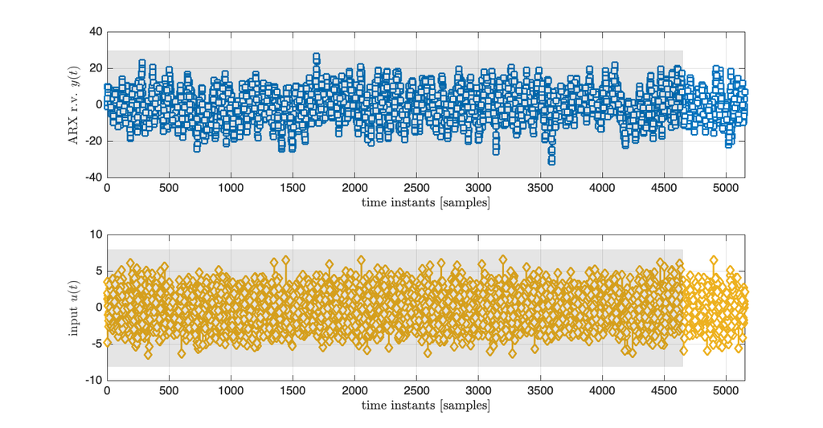

```matlab
figure('Units','normalized', 'Position', [0.1, 0.1, 0.9, 0.75]);
hp1 = subplot(2, 1, 1);
plot(V_ARX_tot, 'Color', FrenchBlue , 'LineWidth', 1.5, 'LineStyle','-', 'Marker','square', ...
      'MarkerSize', 6, 'MarkerEdgeColor','auto', 'MarkerFaceColor','auto');
grid on; hold on;
xlabel('time instants [samples]', 'Interpreter','latex');
ylabel('ARX r.v. $y(t)$', 'Interpreter','latex');
xlim([0, numel(V_ARX_tot)]); % adjusting the x-axis limits
% the gray part corresponds to the transient part of the whitening filter response
YL = ylim;
fill([1 ,Ntransient(end), Ntransient(end), 1], [YL(1), YL(1), YL(2), YL(2)],...
       'k', 'FaceAlpha', 0.10, 'EdgeColor', 'k', 'EdgeAlpha', 0.10);

hp2 = subplot(2, 1, 2);
plot(U_samples, 'Color', Xanthous , 'LineWidth', 1.5, 'LineStyle','-', 'Marker','diamond', ...
      'MarkerSize', 6, 'MarkerEdgeColor','auto', 'MarkerFaceColor','auto');
grid on; hold on;
xlabel('time instants [samples]', 'Interpreter','latex');
ylabel('input $u(t)$', 'Interpreter','latex');
xlim([0, numel(V_ARX_tot)]); % adjusting the x-axis limits
% the gray part corresponds to the transient part of the whitening filter response
YL = ylim;
fill([1 ,Ntransient(end), Ntransient(end), 1], [YL(1), YL(1), YL(2), YL(2)],...
       'k', 'FaceAlpha', 0.10, 'EdgeColor', 'k', 'EdgeAlpha', 0.10);
linkaxes([hp1, hp2], 'x');
```

### Persistency of Excitation and the Identifiability Condition

The regressor $\varphi(t)$ is given by

$\varphi(t) = \left[ \begin{array}{c} y(t-1) \\ y(t-2) \\ u(t-1)\\ u(t-2) \end{array} \right]$

and consequently, the matrices S and R take on the expressions

$S(N_1) = \left [ \begin{array}{cccc} {\displaystyle \sum_{t=3}^{N_1} \left[y(t-1)\right]^2} & {\displaystyle \sum_{t=3}^{N_1} y(t-1) y(t-2)} & {\displaystyle \sum_{t=3}^{N_1} y(t-1) u(t-1)} & {\displaystyle \sum_{t=3}^{N_1} y(t-1) u(t-2)} \\ {\displaystyle \sum_{t=3}^{N_1} y(t-2) y(t-1)} & {\displaystyle \sum_{t=3}^{N_1} \left[y(t-2)\right]^2} & {\displaystyle \sum_{t=3}^{N_1} y(t-2) u(t-1)} & {\displaystyle \sum_{t=3}^{N_1} y(t-2) u(t-2)} \\ {\displaystyle \sum_{t=3}^{N_1} u(t-1) y(t-1)} & {\displaystyle \sum_{t=3}^{N_1} u(t-1) y(t-2)} & {\displaystyle \sum_{t=3}^{N_1} \left[u(t-1)\right]^2} & {\displaystyle \sum_{t=3}^{N_1} u(t-1) u(t-2)} \\ {\displaystyle \sum_{t=3}^{N_1} u(t-2) y(t-1)} & {\displaystyle \sum_{t=3}^{N_1} u(t-2) y(t-2)} & {\displaystyle \sum_{t=3}^{N_1} u(t-2) u(t-1)} & {\displaystyle \sum_{t=3}^{N_1} \left[u(t-2)\right]^2} \end{array} \right ] \qquad R\left( N_1\right) = \displaystyle \frac{1}{N_1-2} S\left(N_1\right)$

Remark: there is a more efficient way to evaluate the matrix S. In fact, given $N_1$ observations, we build the following matrices and vectors

$\Phi_{N_1} = \left [ \begin{array}{c} \varphi(1)^{\top} \\ \vdots \\ \varphi(N_1)^{\top} \end{array} \right ] \quad \varphi (t)= \left [ \begin{array}{c} y(t-1) \\ y(t-2) \\ u(t-1) \\ u(t-2) \end{array} \right ] \qquad \vartheta = \left [ \begin{array}{c} a_1 \\ a_2 \\ b_1 \\ b_2 \end{array} \right ] \qquad Y_{N} = \left [ \begin{array}{c} y(1) \\ \vdots \\ y(N_1) \end{array} \right ]$

Now rewrite the LS problem in a compact form as

$\Phi_{N_1}\cdot \vartheta = Y_{N_1}$

To obtain the LS normal equations in compact form, simply multiply both terms of this expression to the left using the transposed matrix $\Phi_{N_1}^{\top}$:

$\Phi_{N_1}^{\top} \, \Phi_{N_1}\,\vartheta = \Phi_{N_1}^{\top} \, Y_{N_1}$

Finally

$S = \Phi_{N_1}^{\top} \, \Phi_{N_1}$

Now we may

- check if $\Phi_{N_1}^{\top} \, \Phi_{N_1}$ is a full rank matrix (i.e. if the identifiability condition is fulfilled);
- check if the sub-matrix $S_{uu}$ is full-rank (i.e. if we have persistency of excitation - a necessary condition for the identifiability condition to hold true)

$S_{uu}(N_1) = \left [ \begin{array}{cc} {\displaystyle \sum_{t=3}^{N_1} \left[u(t-1)\right]^2} & {\displaystyle \sum_{t=3}^{N_1} u(t-1) u(t-2)} \\ {\displaystyle \sum_{t=3}^{N_1} u(t-2) u(t-1)} & {\displaystyle \sum_{t=3}^{N_1} \left[u(t-2)\right]^2} \end{array} \right ]$

#### The Identifiability Condition

```matlab
U = U_samples(Ntransient+1:end);
Y = V_ARX;
matPHI = zeros(N1-1, 4); % preallocation of the PHI regressors matrix

for k=3:N1
    matPHI(k,:) = [Y(k-1), Y(k-2), U(k-1), U(k-2)];
end % for k
matPHI(1:2,:) = []; % we can not evaluate the model for t=1 and t=2
Y_N1 = Y(3:end)';   % we can not evaluate the model for t=1 and t=2

S_N1 = matPHI'*matPHI;
if (rank(S_N1)<4)
    error('Matrix S not invertible! Identifiability condition not fulfilled!')
else
    disp('Matrix S invertible! Identifiability condition fulfilled!')
end
```

Matrix S invertible! Identifiability condition fulfilled!

### Identification - the LS Algorithm

$\hat \vartheta_{N_1} = \left [ \,\sum_{t=1}^{N_1} \,\varphi(t) \, \varphi(t)^{\top} \, \right ]^{-1} \, \sum_{t=1}^{N_1} \, \varphi(t) \, y(t)$

or in compact form (refer to the previous section of the live script where we recall it)

$\Phi_{N_1}\cdot \vartheta = Y_{N_1}$

$\Phi_{N_1}^{\top} \, \Phi_{N_1}\,\vartheta = \Phi_{N_1}^{\top} \, Y_{N_1}$

Thus we may solve the LS equation using the MATLAB operator " \ " using the compact formulation $\Phi_{N_1}\cdot \vartheta = Y_{N_1}$

```matlab
hat_theta_N1 = matPHI \ Y_N1
```

hat_theta_N1 = 4×1

1.1776 -0.2972 0.9878 0.4731

Alternatively, we may solve the LS normal equations $\Phi_{N_1}^{\top} \, \Phi_{N_1}\,\vartheta = \Phi_{N_1}^{\top} \, Y_{N_1}$, exploiting one more time the operator " \ "

```matlab
hat_theta_N1_ALT = S_N1 \ (matPHI'*Y_N1)
```

hat_theta_N1_ALT = 4×1

1.1776 -0.2972 0.9878 0.4731

As can be seen, both approaches lead to the same solution.

### The Estimate Uncertainty

What about the estimate uncertainty?

According to the theoretical result, described in the class material (refer to L12 - p. 24), for N sufficiently large the variance of the estimator is $\frac{1}{N}\,\mathrm{var}\left[\epsilon\left(\vartheta^{o}\right)\right]\,\big[\bar{R}\left(\vartheta^{o}\right)\big]^{-1}$

Computing the empirical estimate, one gets

${\rm var} \, [ \hat \vartheta_N ] = \frac{\hat{\lambda}^2}{N} \, \left [ \frac{1}{N} \, \sum_{t=1}^N \, \varphi(t) \, \varphi(t)^{\top} \right ]^{-1} = \hat{\lambda}^2 \, S(N)^{-1}$

where

$\hat{\lambda}^2 = \frac{1}{N} \sum_{t=1}^{N} \, \left [ y(t)-\varphi(t)^{\top} \hat{\vartheta}_{N} \right ]^2$

In this example one gets

```matlab
% the estimate of the prediction error variance
pred_residuals = Y_N1 - matPHI*hat_theta_N1;
hat_lambda2_N1 = mean((pred_residuals).^2)
```

hat_lambda2_N1 = 0.9470

```matlab
cond(S_N1)
```

ans = 106.3693

```matlab
var_theta_N1 = hat_lambda2_N1 .* inv(S_N1)
```

var_theta_N1 = 4×4

0.0005 -0.0005 0.0000 -0.0006 -0.0005 0.0005 0.0000 0.0005 0.0000 0.0000 0.0005 -0.0000 -0.0006 0.0005 -0.0000 0.0011

Alternatively

```matlab
R_N1 = S_N1 ./ N1;
cond(R_N1)
```

ans = 106.3693

```matlab
var_theta_N1_ALT = (hat_lambda2_N1/N1) .* inv(R_N1)
```

var_theta_N1_ALT = 4×4

0.0005 -0.0005 0.0000 -0.0006 -0.0005 0.0005 0.0000 0.0005 0.0000 0.0000 0.0005 -0.0000 -0.0006 0.0005 -0.0000 0.0011

### The Witheness Test

What about the prediction residuals? Are they samples of a stationary stochastic white noise process or?

Actually we have the prediction residuals, so let us apply the Anderson's whiteness test

```matlab
WTest_result = AndersonWhitenessTest(pred_residuals, 0.01, true)
```

AndersonWhitenessTest: confidence level 0.010000 AndersonWhitenessTest: max lag value M 24 AndersonWhitenessTest: critical value 0 AndersonWhitenessTest: accept the hypothesis --> the prediction error IS a stationary white noise stochastic process

WTest_result = 0